# CP001: Regresión y Salarios NBA

### Modelo 3

```r
regres03<- lm(Salary ~ NBA_DraftNumber + Age+ TRB.+ WS, data = data)
summary(regres03)
```

```
##
## Call:
## lm(formula = Salary ~ NBA_DraftNumber + Age + TRB. + WS, data = data)
##
## Residuals:
##       Min        1Q    Median        3Q       Max
## -14594852  -3541030   -421333   2271697  24498107
##
## Coefficients:
##                 Estimate Std. Error t value Pr(>|t|)
## (Intercept)     -7067421    1701376  -4.154 3.87e-05 ***
## NBA_DraftNumber   -76872      12494  -6.153 1.61e-09 ***
## Age               488752      58489   8.356 7.09e-16 ***
## TRB.              -18841      52353  -0.360    0.719
## WS               1352327     101766  13.289  < 2e-16 ***
## ---
## Signif. codes:  0 '***' 0.001 '**' 0.01 '*' 0.05 '.' 0.1 ' ' 1
##
## Residual standard error: 5430000 on 478 degrees of freedom
## Multiple R-squared:  0.4658, Adjusted R-squared:  0.4613
## F-statistic: 104.2 on 4 and 478 DF,  p-value: < 2.2e-16
```

```r
vif(regres03)
```

```
## NBA_DraftNumber             Age            TRB.              WS
##        1.137859        1.021718        1.086946        1.211021
```

En este tercer modelo se puede observar como el problema de la multicolinealidad ha sido solucionado. No obstante, hay un efecto inesperado. Este es que una variable más (TRB.) deja de ser significativa en este modelo. No fue previamente descartada porque tenía significancia media, pero con esta tercera comprobación se ha descubierto que finalmente no lo es.

## Elección del modelo final, Modelo 4

```r
regres04<- lm(Salary ~ NBA_DraftNumber + Age+ WS, data = data)

summary(regres04)
```

```
##
## Call:
## lm(formula = Salary ~ NBA_DraftNumber + Age + WS, data = data)
##
## Residuals:
##       Min        1Q    Median        3Q       Max
## -14678066  -3516344   -397938   2336165  24462877
##
## Coefficients:
##                 Estimate Std. Error t value Pr(>|t|)
## (Intercept)     -7288602    1585048  -4.598 5.46e-06 ***
## NBA_DraftNumber   -76542      12449  -6.148 1.65e-09 ***
## Age               490463      58243   8.421 4.37e-16 ***
## WS               1343836      98903  13.587  < 2e-16 ***
## ---
## Signif. codes:  0 '***' 0.001 '**' 0.01 '*' 0.05 '.' 0.1 ' ' 1
##
## Residual standard error: 5425000 on 479 degrees of freedom
## Multiple R-squared:  0.4656, Adjusted R-squared:  0.4623
## F-statistic: 139.1 on 3 and 479 DF,  p-value: < 2.2e-16
```

```r
gvlma(regres04)
```

```
##
## Call:
## lm(formula = Salary ~ NBA_DraftNumber + Age + WS, data = data)
##
## Coefficients:
##     (Intercept)  NBA_DraftNumber              Age               WS
##        -7288602           -76542           490463          1343836
##
##
## ASSESSMENT OF THE LINEAR MODEL ASSUMPTIONS
## USING THE GLOBAL TEST ON 4 DEGREES-OF-FREEDOM:
## Level of Significance =  0.05
##
## Call:
##  gvlma(x = regres04)
##
##                       Value   p-value                   Decision
## Global Stat        138.1577 0.000e+00 Assumptions NOT satisfied!
## Skewness            56.9862 4.385e-14 Assumptions NOT satisfied!
## Kurtosis            67.0166 2.220e-16 Assumptions NOT satisfied!
## Link Function       13.3933 2.525e-04 Assumptions NOT satisfied!
## Heteroscedasticity   0.7616 3.828e-01    Assumptions acceptable.
```

```r
vif(regres04)
```

```
## NBA_DraftNumber             Age              WS
##        1.131706        1.014970        1.145924
```

### Estudio de la normalidad y QQ-Plot

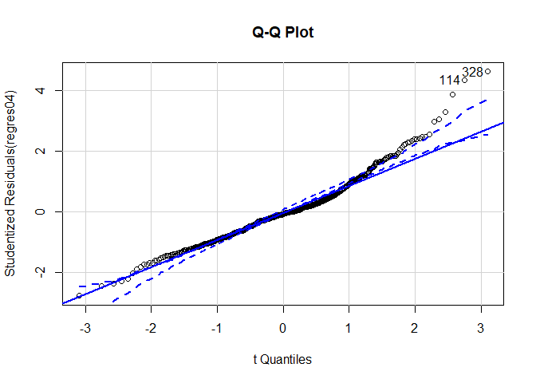

```
## 114 328
## 112 326
```

```r
qqPlot(regres04, labels=row.names(nba), id.method="identify",
       simulate=TRUE, main="Q-Q Plot")
```

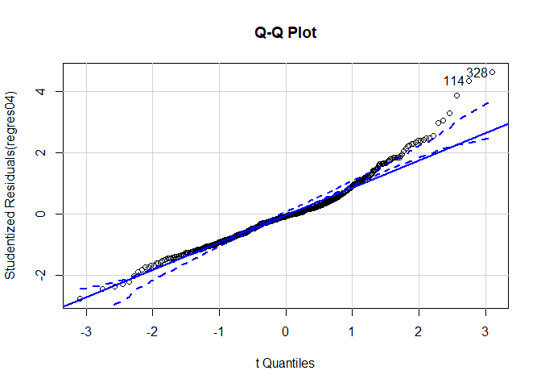

```
## 114 328
## 112 326
```

```r
qqPlot(regres04, labels=row.names(nba), id.method="identify",
       simulate=TRUE, main="Q-Q Plot")
```

Los valores se distribuyen en torno a la media, aunque también se aprecian algunos outliers.

### Test de Jarque Bera

```r
vResid4=resid(regres04)
jbTest(vResid4)
```

```
##
## Title:
##  Jarque - Bera Normality Test
##
## Test Results:
##   PARAMETER:
##     Sample Size: 483
##   STATISTIC:
##     LM: 124.003
##     ALM: 127.767
##   P VALUE:
##     Asymptotic: < 2.2e-16
##
## Description:
##  Wed Oct 28 21:25:42 2020 by user: ajrd9
```

### Test de Shapiro-Wilk

```r
shapiro.test(vResid4)
```

```
##
##  Shapiro-Wilk normality test
##
## data:  vResid4
## W = 0.96003, p-value = 3.584e-10
```

### Test Durbin-Watson

```r
dwtest(regres04)
```

```
##
##  Durbin-Watson test
##
## data:  regres04
## DW = 1.8802, p-value = 0.09352
## alternative hypothesis: true autocorrelation is greater than 0
```

### Linealidad

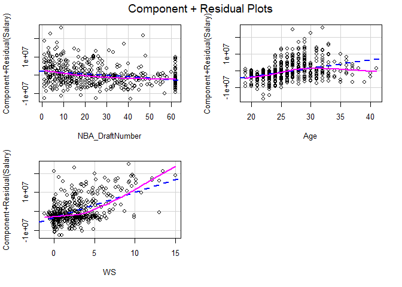

```r
crPlots(regres04)
```

### Estudio de los residuos

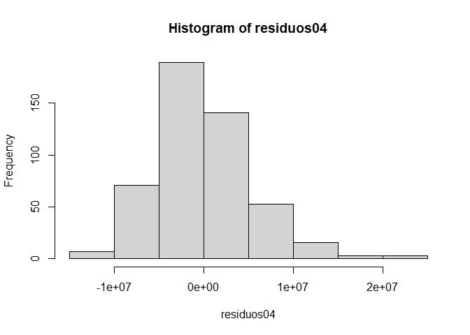

```r
residuos04<- residuals(regres04)

hist(residuos04)
```

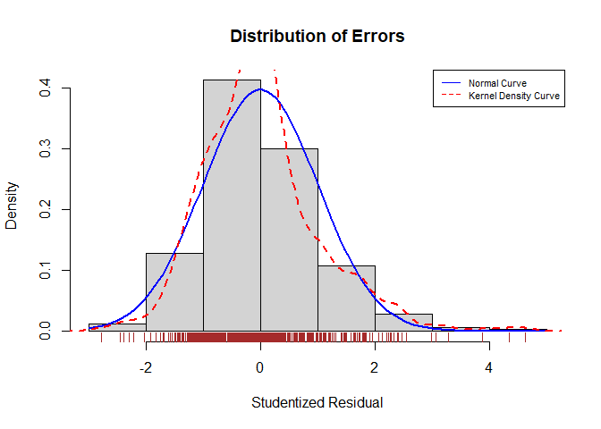

```r
residplot4 <- function(fit, nbreaks=10) {
  z <- rstudent(fit)
  hist(z, breaks=nbreaks, freq=FALSE,
       xlab="Studentized Residual",
       main="Distribution of Errors")
  rug(jitter(z), col="brown")
  curve(dnorm(x, mean=mean(z), sd=sd(z)),
        add=TRUE, col="blue", lwd=2)
  lines(density(z)$x, density(z)$y,
        col="red", lwd=2, lty=2)
  legend("topright",
         legend = c( "Normal Curve", "Kernel Density Curve"),
         lty=1:2, col=c("blue","red"), cex=.7)
}

residplot4(regres04)
```

### Interacción

```r
regresInter=lm(Salary~NBA_DraftNumber*Age*WS,data=nba)
```